# Analisis de mortalidad por causas Argentina 4

Federico Tricarico

2025-07-31

## 1 Intro

Con datos de capítulos anteriores, se analiza la evolución de la mortalidad por causas en Argentina. Los datos de defunciones fueron provistos por la DEIS, y los de población se estimaron mediante interpolación por edad y sexo, de los totales de las rondas censales 2001, 2010 y 2022, dispuestas por INDEC. El indicador para analizar la mortalidad es la **Razón de mortalidad** del trienio según grandes grupo de causas, por edad en tres grandes grupos y sexo, y se calcula como la razón entre las defunciones del trienio por la población estimada al año central de trienio.

$$\text{R}_{m} = \frac{E_{t-1} + E_{t} + E_{t+1}}{P_{t}} \times 100{,}000$$

Donde $E$ son los eventos, del periodo ${t}$ y $P{t}$ es la poblacion estimada al año central del trienio, para cada grupo de causas, edad y sexo.

```r
data <- readRDS("~/GitHub/dinamica_mortalidad/data_salidas/df_defunciones_oms_01_22.rds")
data_pob <- readRDS("~/GitHub/dinamica_mortalidad/data_poblacion/poblacion_final")
```

```r
glimpse(data)
```

```
## Rows: 2,723,936
## Columns: 13
## $ Años                <chr> "2001-2004", "2001-2004", "2001-2004", "2001-2004"…
## $ Provincia           <chr> "Buenos Aires", "Buenos Aires", "Buenos Aires", "B…
## $ Departamento        <chr> "25 de Mayo", "25 de Mayo", "25 de Mayo", "25 de M…
## $ Lugar.de.ocurrencia <chr> "Desconocido", "Desconocido", "Desconocido", "Desc…
## $ Cobertura.médica    <chr> "Desconocido", "Desconocido", "Desconocido", "Desc…
## $ geocodigo           <chr> "6854", "6854", "6854", "6854", "6854", "6854", "6…
## $ geocodigo_provincia <chr> "6", "6", "6", "6", "6", "6", "6", "6", "6", "6", …
## $ gedad               <fct> Menor de 24, Menor de 24, Menor de 24, Menor de 24…
## $ sexo                <chr> "Mujer", "Mujer", "Mujer", "Mujer", "Mujer", "Muje…
## $ CIE10               <chr> "A419", "C56", "C959", "G98", "J690", "K566", "P22…
## $ casos               <int> 1, 1, 1, 1, 1, 1, 1, 1, 1, 1, 1, 1, 1, 2, 1, 1, 1,…
## $ grupo_oms           <chr> "Condiciones transmisibles, maternas, perinatales …
## $ grupo_oms2          <chr> "Enfermedades infecciosas y parasitarias", "Neopla…
```

```r
glimpse(data_pob)
```

```
## Rows: 67,584
## Columns: 5
## $ geocodigo <dbl> 2000, 2000, 2000, 2000, 2000, 2000, 6007, 6007, 6007, 6007, …
## $ sex       <dbl> 1, 1, 1, 2, 2, 2, 1, 1, 1, 2, 2, 2, 1, 1, 1, 2, 2, 2, 1, 1, …
## $ edad      <chr> "0-24", "25-69", "70 y mas", "0-24", "25-69", "70 y mas", "0…
## $ Year      <dbl> 2001, 2001, 2001, 2001, 2001, 2001, 2001, 2001, 2001, 2001, …
## $ pob_est   <dbl> 441499, 696784, 120175, 442083, 840839, 234758, 3206, 4245, …
```

## 2 A nivel nacional

Se observa un marcado descenso de la mortalidad. A excepción de las Condiciones Transmisibles en edades adultos y mayores. Con preeminencia de las enfermedades pulmonares, incluso antes de la Pandemia, la que al final de la serie incrementó sensiblemente la razón por estas causas en el trienio 2020-2022.

Es destacable el hecho que, en el trienio de la Pandemia, que aumentó la razón de defunciones debidas a Enfermedades mal definidas, en las edades adultas y mayores. Al tiempo que para todas las edades se redujo la razón por el resto de causas, esto es una baja punta a punta de las razones debidas a Lesiones o causas externas y Enfermedades no transmisibles

En la siguiente tabla puede observar la evolucion de la Razon de mortalidad en trienios por edad y sexo, segun grandes grupos de causas.

**Ver la tabla**

Razon de mortalidad (x100.000) segun grupo de edad, gran grupo de causas y sexo, en trienios, Argentina

| gedad | grupo_oms | sexo | 2005-2007 | 2008-2010 | 2011-2013 | 2014-2016 | 2017-2019 | 2020-2022 |
| --- | --- | --- | --- | --- | --- | --- | --- | --- |
| Menor de 24 | Condiciones transmisibles, maternas, perinatales y nutricionales | Mujer | 100 | 101 | 90 | 80 | 66 | 54 |
|  |  | Varón | 127 | 122 | 110 | 102 | 84 | 67 |
|  | Enfermedades mal definidas | Mujer | 9 | 10 | 8 | 8 | 7 | 6 |
|  |  | Varón | 14 | 15 | 12 | 12 | 12 | 9 |
|  | Enfermedades no transmisibles | Mujer | 99 | 97 | 94 | 90 | 80 | 65 |
|  |  | Varón | 118 | 119 | 114 | 109 | 97 | 79 |
|  | Lesiones | Mujer | 44 | 42 | 43 | 38 | 36 | 30 |
|  |  | Varón | 133 | 138 | 153 | 141 | 122 | 96 |
| 25 a 69 | Condiciones transmisibles, maternas, perinatales y nutricionales | Mujer | 106 | 109 | 109 | 119 | 116 | 317 |
|  |  | Varón | 179 | 185 | 181 | 192 | 187 | 563 |
|  | Enfermedades mal definidas | Mujer | 62 | 70 | 64 | 52 | 50 | 55 |
|  |  | Varón | 149 | 153 | 136 | 114 | 108 | 115 |
|  | Enfermedades no transmisibles | Mujer | 853 | 831 | 823 | 821 | 787 | 767 |
|  |  | Varón | 1479 | 1398 | 1358 | 1326 | 1248 | 1194 |
|  | Lesiones | Mujer | 62 | 59 | 59 | 55 | 51 | 42 |
|  |  | Varón | 266 | 263 | 262 | 241 | 218 | 189 |
| 70 y mas | Condiciones transmisibles, maternas, perinatales y nutricionales | Mujer | 2526 | 2358 | 2484 | 2911 | 3045 | 4869 |
|  |  | Varón | 3033 | 2872 | 3019 | 3479 | 3603 | 6819 |
|  | Enfermedades mal definidas | Mujer | 1609 | 1747 | 1714 | 1316 | 1229 | 1383 |
|  |  | Varón | 2008 | 2157 | 2036 | 1554 | 1460 | 1602 |
|  | Enfermedades no transmisibles | Mujer | 14724 | 13934 | 13638 | 13512 | 12637 | 12453 |
|  |  | Varón | 19964 | 18625 | 18014 | 17686 | 16483 | 15666 |
|  | Lesiones | Mujer | 342 | 280 | 285 | 303 | 272 | 231 |
|  |  | Varón | 622 | 528 | 507 | 508 | 446 | 389 |

Note:  
Elaboracion propia con datos de DEIS y OMS

## 3 Grafico de evolución

Grafico facetado por causa y grupo de edad, muestra la evolucion de la Razon de Mortalidad en trienios.

```r
x_anios <- c(2006, 2009, 2012, 2015, 2018, 2021)
label_anios <- c("2005-07", "2008-10", "2011-13", "2014-16", "2017-19", "2020-22")
```

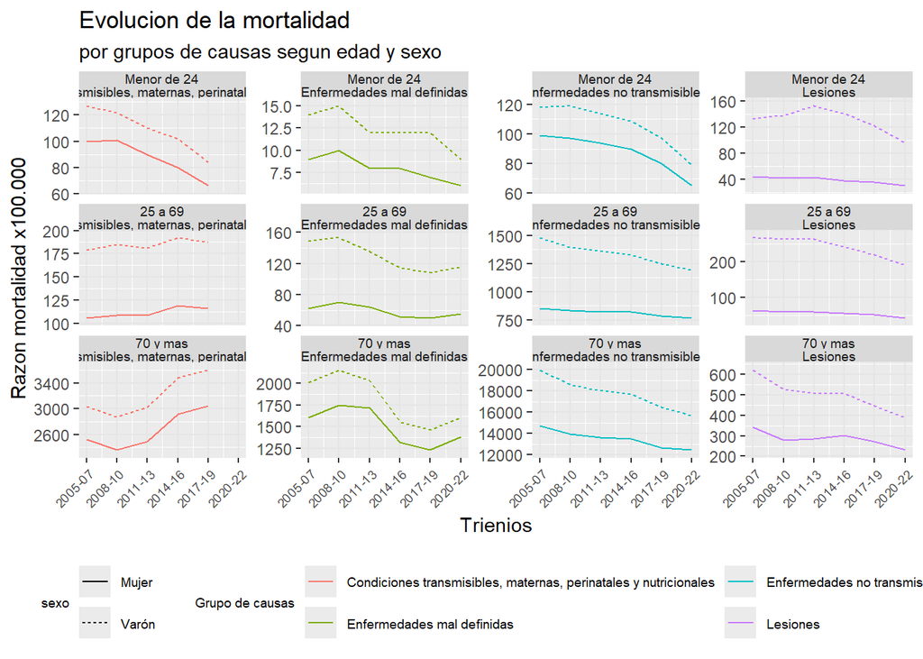

```r
data_mort_nac |>
  mutate(
    rmxm = if_else(
      grupo_oms=="Condiciones transmisibles, maternas, perinatales y nutricionales" & anio == 2021,
      NA,
      rmxm
      )
  ) |>
  filter(anio != 2003) |>
  mutate(
    gedad = factor(gedad, levels = c("Menor de 24", "25 a 69", "70 y mas"), ordered = TRUE)) |>
  ggplot(aes(anio, rmxm, group = sexo, color= grupo_oms))+
  geom_line(aes(linetype = sexo))+
  scale_y_continuous(expand = expansion(mult = .1))+
  scale_x_continuous(breaks = x_anios, labels = label_anios)+
  facet_wrap(~gedad+grupo_oms, ncol=4, scale="free_y")+
  # theme_minimal()+
  theme(
    strip.text = element_text(angle = 0, size = 7, margin = margin()),
    strip.background.x = element_rect(size = 5),
    axis.text.x = element_text(angle = 45, size = 7, hjust = 1),
    legend.position = "bottom",
    legend.justification = "center",
    # legend.key.size = unit(1.5, "cm"),
    legend.text = element_text(size = 7),
    legend.title = element_text(size = 7),
    panel.grid.major.y = element_line(colour = "grey90"),
    panel.grid.major.x = element_line(colour = "grey90")
    # panel.grid.minor = element_blank()
  )+
  labs(
    title = "Evolucion de la mortalidad",
    subtitle = "por grupos de causas segun edad y sexo",
    y="Razon mortalidad x100.000",
    x= "Trienios",
    color = "Grupo de causas"
  )+
  guides(
    color=guide_legend(ncol = 2),
    linetype =guide_legend(nrow = 2)
         )
```

```r
# ggsave("~/GitHub/dinamica_mortalidad/salida_graf/grafico1.png")
```

## 4 Variación

Para observar la variacion se puede comparar el inicio de la serie, con el ultimo trienio 2017-2019 antes y durante la Pandemia en el trienio 2020-2022.

**Click for Answer**

Variacion Razon de Mortalidad segun causa, sexo y edad

| gedad | grupo_oms | sexo | rmxm_2006 | rmxm_2018 | rmxm_2021 | TC_2018 | TC_2021 |
| --- | --- | --- | --- | --- | --- | --- | --- |
| Menor de 24 | Condiciones transmisibles, maternas, perinatales y nutricionales | Mujer | 100 | 66 | 54 | -34.0% | -18.2% |
|  |  | Varón | 127 | 84 | 67 | -33.9% | -20.2% |
|  | Enfermedades mal definidas | Mujer | 9 | 7 | 6 | -22.2% | -14.3% |
|  |  | Varón | 14 | 12 | 9 | -14.3% | -25.0% |
|  | Enfermedades no transmisibles | Mujer | 99 | 80 | 65 | -19.2% | -18.8% |
|  |  | Varón | 118 | 97 | 79 | -17.8% | -18.6% |
|  | Lesiones | Mujer | 44 | 36 | 30 | -18.2% | -16.7% |
|  |  | Varón | 133 | 122 | 96 | -8.3% | -21.3% |
| 25 a 69 | Condiciones transmisibles, maternas, perinatales y nutricionales | Mujer | 106 | 116 | 317 | 9.4% | 173.3% |
|  |  | Varón | 179 | 187 | 563 | 4.5% | 201.1% |
|  | Enfermedades mal definidas | Mujer | 62 | 50 | 55 | -19.4% | 10.0% |
|  |  | Varón | 149 | 108 | 115 | -27.5% | 6.5% |
|  | Enfermedades no transmisibles | Mujer | 853 | 787 | 767 | -7.7% | -2.5% |
|  |  | Varón | 1479 | 1248 | 1194 | -15.6% | -4.3% |
|  | Lesiones | Mujer | 62 | 51 | 42 | -17.7% | -17.6% |
|  |  | Varón | 266 | 218 | 189 | -18.0% | -13.3% |
| 70 y mas | Condiciones transmisibles, maternas, perinatales y nutricionales | Mujer | 2526 | 3045 | 4869 | 20.5% | 59.9% |
|  |  | Varón | 3033 | 3603 | 6819 | 18.8% | 89.3% |
|  | Enfermedades mal definidas | Mujer | 1609 | 1229 | 1383 | -23.6% | 12.5% |
|  |  | Varón | 2008 | 1460 | 1602 | -27.3% | 9.7% |
|  | Enfermedades no transmisibles | Mujer | 14724 | 12637 | 12453 | -14.2% | -1.5% |
|  |  | Varón | 19964 | 16483 | 15666 | -17.4% | -5.0% |
|  | Lesiones | Mujer | 342 | 272 | 231 | -20.5% | -15.1% |
|  |  | Varón | 622 | 446 | 389 | -28.3% | -12.8% |

Note:  
Elaboracion propia con datos de DEIS y OMS

## 5 Conclusiones

Este análisis, permite observar el perfil epidemiológico de argentina en el siglo XXI. En primer lugar, por la simpleza que deriva de usar 3 grandes grupos de edad y cuatro grandes grupos de causas, diferenciando siempre por sexo. En segundo lugar, porque utiliza datos disponibles de una serie homogénea y con gran cobertura de eventos, aunque la calidad pueda ser cuestionada, lo que será analizado más adelante.

Se destaca la relevancia de las Enfermedades Crónicas No Transmisibles para explicar tanto el nivel de la Mortalidad, como el descenso reciente. Sin embargo, lo mas destacable del descenso, esta en las defunciones debidas a Enfermedades Transmisibles, maternas y perinatales en las edades jóvenes. Aunque se advierten fenómenos como los de reemergencias epidemiológicas considerando el aumento previo a la Pandemia de la mortalidad por estas causas Infecto contagiosas, en edades adultos y mayores.